# diff_exp

Changhua Yu

2/15/2021

### Bioconductor and CRAN libraries used

```r
## Setup
library(tidyverse)
library(RColorBrewer)
library(DESeq2)
```

```r
library(pheatmap)
library(DEGreport)
library(factoextra)
library("edgeR")
library("ggplot2")
library("dplyr")
library("ggrepel")
```

## Read in raw count transcript matrix

```r
raw_counts <- read.table("../data/transcript_count_matrix.csv", header=T, row.names=1,sep = ",")
# filter out count rows with either fewer than 10 counts or over 4000 counts
filt_sel = rowSums(raw_counts[,1:10]>=10)>0
raw_counts = raw_counts[filt_sel,]
dim(raw_counts)
```

```
## [1] 21862    10
```

```r
filt_sel = rowSums(raw_counts[,1:10]<4000)>0
raw_counts = raw_counts[filt_sel,]
dim(raw_counts)
```

```
## [1] 21792    10
```

### Read in sample treatment and annotation as metadata

```r
sample_anno = read.csv("../data/sample_name_Aurelia.csv",header = FALSE,stringsAsFactors = FALSE)
colnames(raw_counts) = as.character(rev(sample_anno$V4))
metadata = read.table("../data/metadata.txt", header=T, row.names=1,sep = ",")
metadata
```

```
##                sample         srr  treatment    amputation regeneration
## treat_27_2 treat_27_2 SRR12953056 treated_27     amputated      excited
## treat_27_1 treat_27_1 SRR12953057 treated_27     amputated  non_excited
## blank_2       blank_2 SRR12953058      blank pre_amputated        blank
## blank_1       blank_1 SRR12953059      blank pre_amputated        blank
## ctrl_51_2   ctrl_51_2 SRR12953060    ctrl_51     amputated  non_excited
## ctrl_51_1   ctrl_51_1 SRR12953061    ctrl_51     amputated  non_excited
## treat_51_2 treat_51_2 SRR12953062 treated_51     amputated      excited
## treat_51_1 treat_51_1 SRR12953063 treated_51     amputated      excited
## ctrl_27_2   ctrl_27_2 SRR12953064    ctrl_27     amputated  non_excited
## ctrl_27_1   ctrl_27_1 SRR12953065    ctrl_27     amputated  non_excited
##                  response
## treat_27_2     excited_27
## treat_27_1 non_excited_27
## blank_2             blank
## blank_1             blank
## ctrl_51_2  non_excited_51
## ctrl_51_1  non_excited_51
## treat_51_2     excited_51
## treat_51_1     excited_51
## ctrl_27_2  non_excited_27
## ctrl_27_1  non_excited_27
```

### Build DESeq2 object

```r
all(colnames(raw_counts) == rownames(metadata))
```

```
## [1] TRUE
```

```r
dds <- DESeqDataSetFromMatrix(countData = raw_counts, colData = metadata, design = ~ treatment)
```

### Apply a regularized log transformation on raw count for PCA visualization of samples

> This function transforms the count data to the log2 scale in a way which minimizes differences between samples for rows with small counts, and which normalizes with respect to library size.

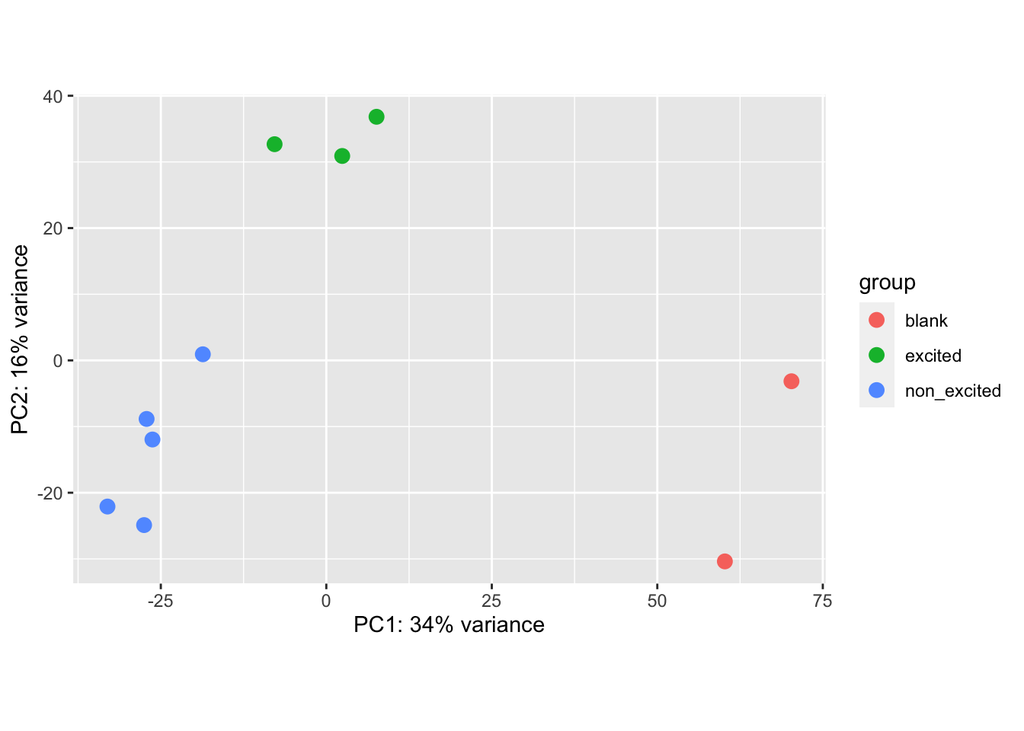

```r
rld <- rlog(dds, blind=TRUE)
# color by whether a regeneration response is excited
plotPCA(rld, intgroup="regeneration")
```

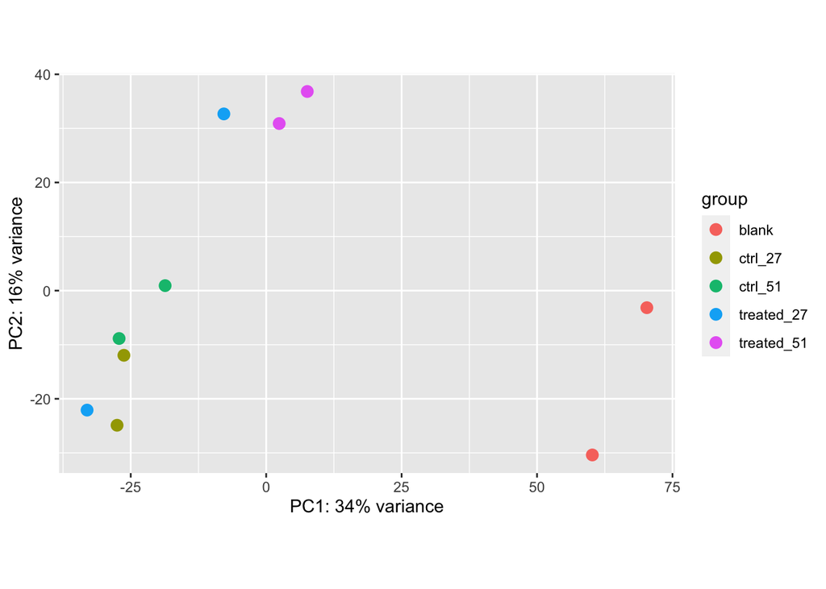

```r
# color by the feeding/non-feeding/0hr blank
plotPCA(rld, intgroup="treatment")
```

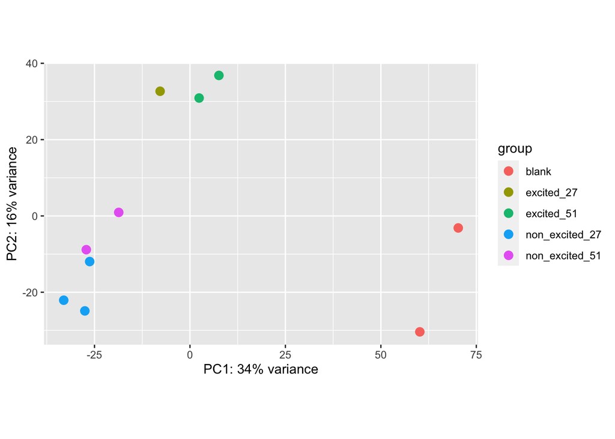

```r
# color by the whether is regeneration response is stimulated
plotPCA(rld, intgroup="response")
```

> Observation: 1. Preamputation VS amputated samples are clearly separated by the PC1 2. Treat_27_2 Treat_51_1, and Treat_51_2 is well-separated from the other amputated sample, indicating potentially Treat_27_1 does not show a significant difference from other non-feeding populations

### Build up DESeq object and output the normalized counts

```r
dds <- DESeq(dds)
normalized_counts <- counts(dds, normalized=TRUE)
# write.csv(normalized_counts,file = "../data/normalized_counts.csv")
```

## DESeq2: Comparison groups to Pre-Amputation VS Amputation

```r
dds <- DESeqDataSetFromMatrix(countData = raw_counts, colData = metadata, design = ~ amputation)
dds <- DESeq(dds)
```

```
## -- replacing outliers and refitting for 514 genes
## -- DESeq argument 'minReplicatesForReplace' = 7
## -- original counts are preserved in counts(dds)
```

```r
#amputation VS pre-amputation
contrast.ampu = c("amputation", "amputated", "pre_amputated")
# Output results of Wald test for contrast
res.ampu <- results(dds, contrast = contrast.ampu)
### Set thresholds
padj.cutoff <- 0.05
lfc.cutoff <- 1.5
res.ampu.tb <- res.ampu %>%
  data.frame() %>%
  rownames_to_column(var="gene") %>%
  as_tibble()
res.ampu.sig <- res.ampu.tb %>%
        dplyr::filter(padj < padj.cutoff & abs(log2FoldChange) > lfc.cutoff)

head(res.ampu.sig)
```

```
## # A tibble: 6 x 7
##   gene              baseMean log2FoldChange lfcSE  stat    pvalue     padj
##   <chr>                <dbl>          <dbl> <dbl> <dbl>     <dbl>    <dbl>
## 1 Seg1.9               314.            1.74 0.504  3.46 0.000543  0.00889
## 2 Seg3.10               50.7           2.54 0.594  4.28 0.0000187 0.000596
## 3 Seg3.15              619.            2.25 0.664  3.38 0.000725  0.0111
## 4 Seg3.23             3080.           -1.84 0.427 -4.31 0.0000163 0.000537
## 5 Seg6.6              1472.            2.34 0.545  4.29 0.0000179 0.000576
## 6 Seg6.6.1.57f48f7c     10.4           5.73 1.48   3.87 0.000111  0.00258
```

## DESeq2: Set the comparison groups to Excited regeneration (feeding except treat_27_1) VS ctrl level (non-excited)

```r
dds <- DESeqDataSetFromMatrix(countData = raw_counts, colData = metadata, design = ~regeneration)
dds <- DESeq(dds)
contrast.rege = c("regeneration", "excited", "non_excited")
# Output results of Wald test for contrast
res.rege <- results(dds, contrast = contrast.rege)
### Set thresholds
padj.cutoff <- 0.05
lfc.cutoff <- 1.5
res.rege.tb <- res.rege %>%
  data.frame() %>%
  rownames_to_column(var="gene") %>%
  as_tibble()
res.rege.sig <- res.rege.tb %>%
        dplyr::filter(padj < padj.cutoff & abs(log2FoldChange) > lfc.cutoff)

head(res.rege.sig)
```

```
## # A tibble: 6 x 7
##   gene    baseMean log2FoldChange lfcSE  stat   pvalue         padj
##   <chr>      <dbl>          <dbl> <dbl> <dbl>    <dbl>        <dbl>
## 1 Seg3.15    619.           -1.61 0.380 -4.22 2.39e- 5 0.00151
## 2 Seg5.10     20.6           8.26 1.96   4.21 2.55e- 5 0.00158
## 3 Seg6.7     161.            1.78 0.565  3.14 1.67e- 3 0.0373
## 4 Seg10.4     14.2           7.38 1.10   6.70 2.03e-11 0.0000000141
## 5 Seg16.5    120.            1.50 0.346  4.33 1.48e- 5 0.00103
## 6 Seg18.9     13.2           2.49 0.807  3.08 2.07e- 3 0.0430
```

## DESeq2: Set the comparison groups to Excited regeneration VS ctrl level at 27h

```r
dds <- DESeqDataSetFromMatrix(countData = raw_counts, colData = metadata, design = ~response)
dds <- DESeq(dds)
contrast.rege27 = c("response", "excited_27", "non_excited_27")
# Output results of Wald test for contrast
res.rege27 <- results(dds, contrast = contrast.rege27)
### Set thresholds
padj.cutoff <- 0.05
lfc.cutoff <- 1.5
res.rege27.tb <- res.rege27 %>%
  data.frame() %>%
  rownames_to_column(var="gene") %>%
  as_tibble()
res.rege27.sig <- res.rege27.tb %>%
        dplyr::filter(padj < padj.cutoff & abs(log2FoldChange) > lfc.cutoff)

head(res.rege27.sig)
```

```
## # A tibble: 6 x 7
##   gene    baseMean log2FoldChange lfcSE  stat       pvalue      padj
##   <chr>      <dbl>          <dbl> <dbl> <dbl>        <dbl>     <dbl>
## 1 Seg1.9     314.           -1.82 0.538 -3.38 0.000731     0.0127
## 2 Seg3.15    619.           -1.95 0.548 -3.57 0.000363     0.00818
## 3 Seg3.17     27.2           3.30 1.06   3.11 0.00184      0.0238
## 4 Seg5.1      67.3           2.79 0.934  2.99 0.00281      0.0309
## 5 Seg5.10     20.6           9.44 3.30   2.86 0.00424      0.0402
## 6 Seg6.7     161.            3.09 0.565  5.47 0.0000000456 0.0000123
```

## DESeq2: Set the comparison groups to Excited regeneration VS ctrl level at 51h

```r
dds <- DESeqDataSetFromMatrix(countData = raw_counts, colData = metadata, design = ~response)
dds <- DESeq(dds)
contrast.rege51 = c("response", "excited_51", "non_excited_51")
# Output results of Wald test for contrast
res.rege51 <- results(dds, contrast = contrast.rege51)
### Set thresholds
padj.cutoff <- 0.05
lfc.cutoff <- 1.5
res.rege51.tb <- res.rege51 %>%
  data.frame() %>%
  rownames_to_column(var="gene") %>%
  as_tibble()
res.rege51.sig <- res.rege51.tb %>%
        dplyr::filter(padj < padj.cutoff & abs(log2FoldChange) > lfc.cutoff)

head(res.rege51.sig)
```

```
## # A tibble: 6 x 7
##   gene     baseMean log2FoldChange lfcSE  stat      pvalue      padj
##   <chr>       <dbl>          <dbl> <dbl> <dbl>       <dbl>     <dbl>
## 1 Seg6.8       22.7           8.02 2.40   3.34 0.000836    0.0383
## 2 Seg10.4      14.2           7.57 1.86   4.06 0.0000492   0.00494
## 3 Seg18.7     775.           -1.68 0.326 -5.14 0.000000278 0.0000843
## 4 Seg23.13     22.9           7.69 1.70   4.53 0.00000583  0.00101
## 5 Seg31.1      13.2           7.92 1.89   4.19 0.0000283   0.00347
## 6 Seg34.8     114.            2.86 0.720  3.97 0.0000707   0.00625
```

### Add annotation of Mus musculus genes to jellyfish transript id

```r
blastx_anno = read.csv("../out/blastx_aurelia_mus.txt",sep = "\t",header = TRUE,stringsAsFactors = FALSE)
# keep only the first one for each of the query entry (lowest e-value)
blastx_anno = blastx_anno %>% group_by(query.acc.ver) %>% dplyr::slice(1)
```

```r
add_mus_anno = function(df,by_left = "gene",out.name) {
  df_merged = merge(df,blastx_anno,by.x = by_left,by.y = "query.acc.ver")
  df_merged_anno = dplyr::select(df_merged,c(by_left,"log2FoldChange","padj","subject.acc.ver","evalue"))
  df_merged_anno.up = df_merged_anno %>% dplyr::filter(log2FoldChange>0) %>% arrange(desc(log2FoldChange))
  df_merged_anno.do = df_merged_anno %>% dplyr::filter(log2FoldChange<0) %>% arrange(log2FoldChange)
  write.csv(df_merged_anno,file = paste0(out.name,".csv"),quote = FALSE)
  write.csv(df_merged_anno.up,file = paste0(out.name,"_up_",".csv"),quote = FALSE)
  write.csv(df_merged_anno.do,file = paste0(out.name,"_do_",".csv"),quote = FALSE)
}
```

### Output the DGE result for the 4 comparisons with both, up and down table as .csv files

```r
add_mus_anno(res.rege.sig,"gene","../out/210215/res.rege.sig")
add_mus_anno(res.rege27.sig,"gene","../out/210215/res.rege27.sig")
add_mus_anno(res.rege51.sig,"gene","../out/210215/res.rege51.sig")
add_mus_anno(res.ampu.sig,"gene","../out/210215/res.ampu.sig")
```

### gProfiler output are enriched from the mapped mus musculus result of DGE output from the above code

## Result Visualization

### plot function 1: plot expression of a single gene

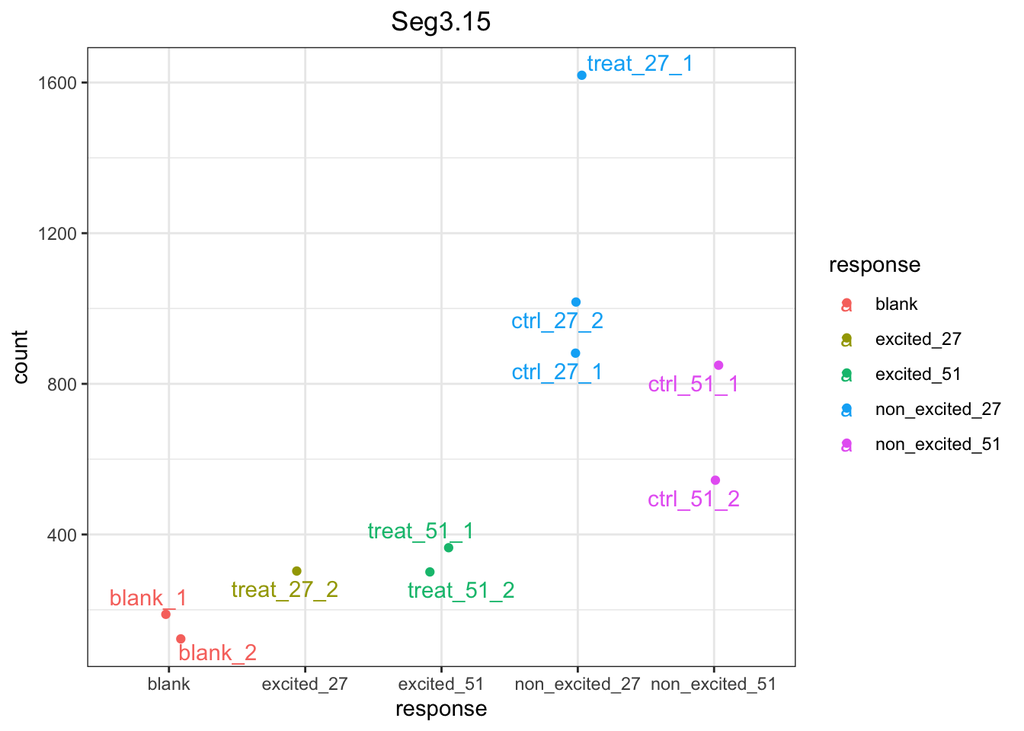

```r
d <- plotCounts(dds, gene="Seg3.15", intgroup="response", returnData=TRUE)
# Plotting the MOV10 normalized counts, using the samplenames (rownames of d as labels)
ggplot(d, aes(x = response, y = count, color = response)) +
  geom_point(position=position_jitter(w = 0.1,h = 0)) +
  geom_text_repel(aes(label = rownames(d))) +
  theme_bw() +
  ggtitle("Seg3.15") +
  theme(plot.title = element_text(hjust = 0.5))
```

### plot function 2: plot multiple genes (e.g. top 20)

```r
normalized_counts <- normalized_counts %>%
  data.frame() %>%
  rownames_to_column(var="gene") %>%
  as_tibble()

## Order results by padj values
top20_sigOE_genes <- res.rege.sig %>%
        arrange(padj) %>%   #Arrange rows by padj values
        pull(gene) %>%      #Extract character vector of ordered genes
        head(n=20)      #Extract the first 20 genes

## normalized counts for top 20 significant genes
top20_sigOE_norm <- normalized_counts %>%
        dplyr::filter(gene %in% top20_sigOE_genes)
head(top20_sigOE_norm)
```

```
## # A tibble: 6 x 11
##   gene  treat_27_2 treat_27_1 blank_2 blank_1 ctrl_51_2 ctrl_51_1 treat_51_2
##   <chr>      <dbl>      <dbl>   <dbl>   <dbl>     <dbl>     <dbl>      <dbl>
## 1 Seg2…       29.8        0      65.6    53.6        0        0         45.3
## 2 Seg6…      132.         0     227.    155.         0        0         97.6
## 3 Seg4…       97.5      242.     92.5   105.       234.     269.        77.4
## 4 Seg5…       34.7        0      41.6    47.2        0        0         70.3
## 5 Seg5…        0         83.7     0       0          0        0          0
## 6 Seg7…      261.        80.7   280.    263.       119.      93.9      337.
## # … with 3 more variables: treat_51_1 <dbl>, ctrl_27_2 <dbl>, ctrl_27_1 <dbl>
```

```r
# Gathering the columns to have normalized counts to a single column
gathered_top20_sigOE <- top20_sigOE_norm %>%
  gather(colnames(top20_sigOE_norm)[2:11], key = "sample", value = "normalized_counts")

gathered_top20_sigOE <- inner_join(metadata, gathered_top20_sigOE)
head(gathered_top20_sigOE)
```

```
##       sample         srr  treatment amputation regeneration   response
## 1 treat_27_2 SRR12953056 treated_27  amputated      excited excited_27
## 2 treat_27_2 SRR12953056 treated_27  amputated      excited excited_27
## 3 treat_27_2 SRR12953056 treated_27  amputated      excited excited_27
## 4 treat_27_2 SRR12953056 treated_27  amputated      excited excited_27
## 5 treat_27_2 SRR12953056 treated_27  amputated      excited excited_27
## 6 treat_27_2 SRR12953056 treated_27  amputated      excited excited_27
##                 gene normalized_counts
## 1           Seg23.13          29.75203
## 2 Seg68.8.3.57f48f7d         132.23123
## 3           Seg418.8          97.52053
## 4           Seg508.4          34.71070
## 5           Seg530.1           0.00000
## 6           Seg700.1         261.15668
```

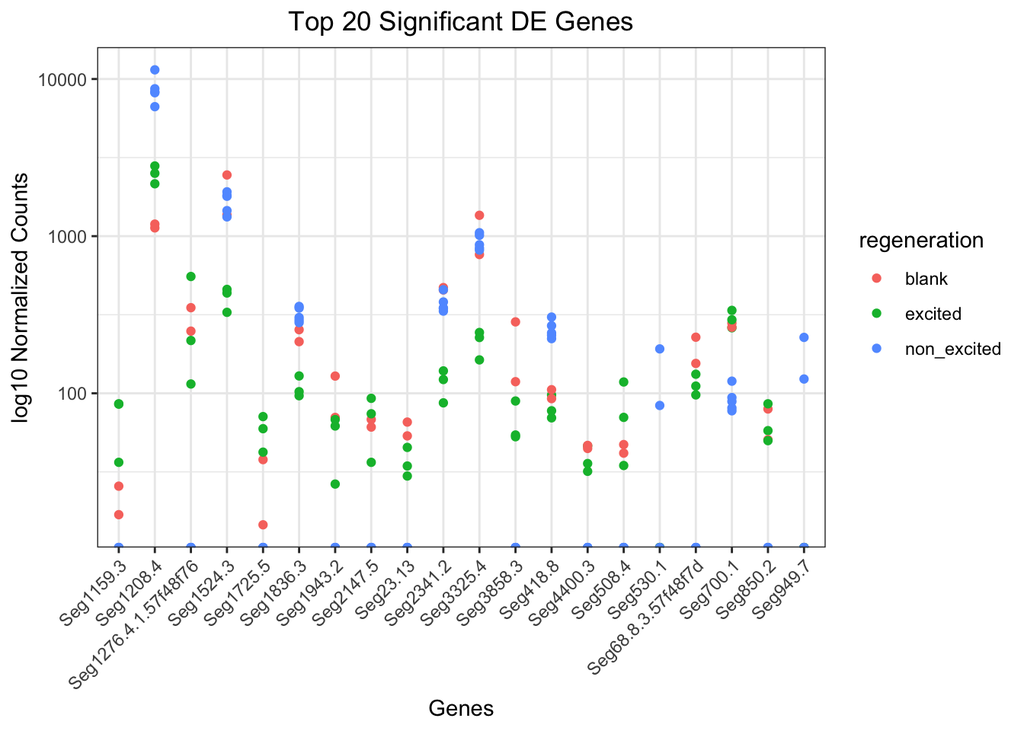

```r
## plot using ggplot2
ggplot(gathered_top20_sigOE) +
        geom_point(aes(x = gene, y = normalized_counts, color = regeneration)) +
        scale_y_log10() +
        xlab("Genes") +
        ylab("log10 Normalized Counts") +
        ggtitle("Top 20 Significant DE Genes") +
        theme_bw() +
    theme(axis.text.x = element_text(angle = 45, hjust = 1)) +
    theme(plot.title = element_text(hjust = 0.5))
```

### plot function 3: Heatmap

#### Heatmap of top 1000 genes of Pre-amputation VS amputation order by padj

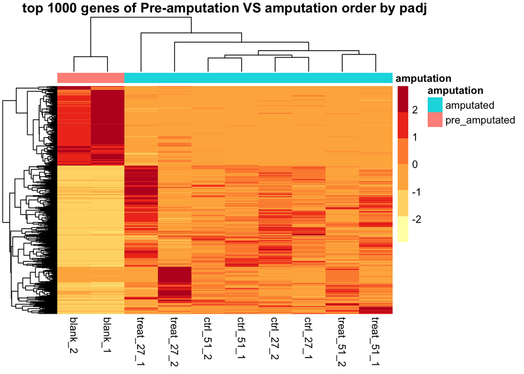

```r
# top 1000 gene order by padj value
gene.ls = c(res.ampu.sig %>% arrange(padj) %>% select(gene))$gene[1:1000]
# res.ampu.sig
norm_OEsig <- normalized_counts[,c(1,2,3,4,5,6,7,8,9,10,11)] %>%
              filter(gene %in% gene.ls) %>%
          data.frame() %>%
          column_to_rownames(var = "gene")
# normalized_counts
# norm_OEsig

### Annotate our heatmap (optional)
annotation <- metadata %>%
    select(sample, amputation) %>%
    data.frame(row.names = "sample")
# annotation
### Set a color palette
heat_colors <- brewer.pal(6, "YlOrRd")

### Run pheatmap
pheatmap(norm_OEsig,
         color = heat_colors,
         cluster_rows = T,
         show_rownames = F,
         annotation = annotation,
         border_color = NA,
         fontsize = 10,
         scale = "row",
         fontsize_row = 10,
         height = 20,
         main = "top 1000 genes of Pre-amputation VS amputation order by padj")
```

#### Heatmap of non-regenerate VS regenerate samples (both 27h and 51h)

```r
norm_OEsig <- normalized_counts[,c(1,2,3,6,7,8,9,10,11)] %>%
              filter(gene %in% res.rege.sig$gene) %>%
          data.frame() %>%
          column_to_rownames(var = "gene")
# normalized_counts
# norm_OEsig

### Annotate our heatmap (optional)
annotation <- metadata %>%
    select(sample, regeneration) %>%
    data.frame(row.names = "sample")
annotation
```

```
##            regeneration
## treat_27_2      excited
## treat_27_1  non_excited
## blank_2           blank
## blank_1           blank
## ctrl_51_2   non_excited
## ctrl_51_1   non_excited
## treat_51_2      excited
## treat_51_1      excited
## ctrl_27_2   non_excited
## ctrl_27_1   non_excited
```

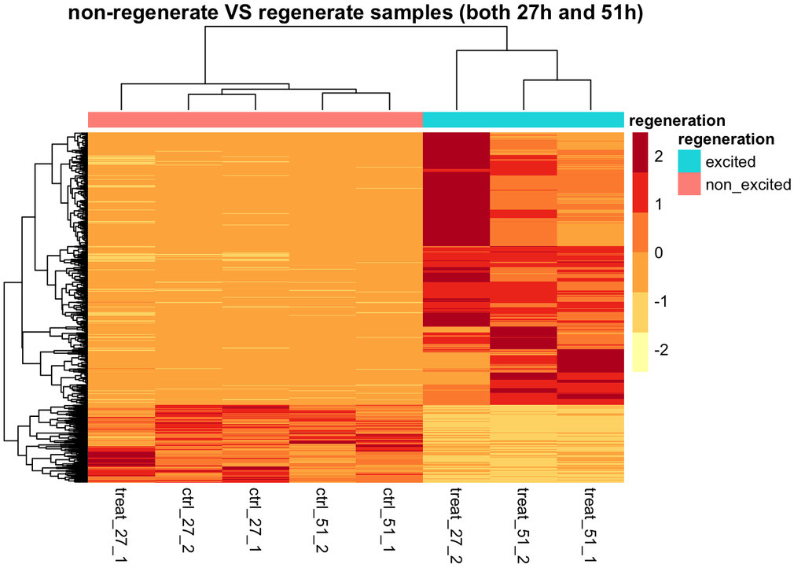

```r
### Set a color palette
heat_colors <- brewer.pal(6, "YlOrRd")

### Run pheatmap
pheatmap(norm_OEsig,
         color = heat_colors,
         cluster_rows = T,
         show_rownames = F,
         annotation = annotation,
         border_color = NA,
         fontsize = 10,
         scale = "row",
         fontsize_row = 10,
         height = 20,
         main = "non-regenerate VS regenerate samples (both 27h and 51h)")
```

### Plotting function 4: Volcano plot

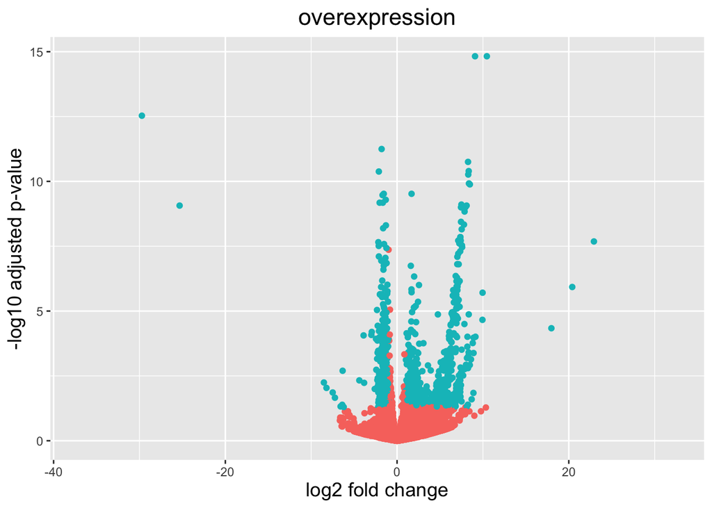

```r
res_tableOE_tb <- res.rege.tb %>%
                  mutate(threshold_OE = padj < 0.05 & abs(log2FoldChange) >= 1)
## Volcano plot
ggplot(res_tableOE_tb) +
        geom_point(aes(x = log2FoldChange, y = -log10(padj), colour = threshold_OE)) +
        ggtitle("overexpression") +
        xlab("log2 fold change") +
        ylab("-log10 adjusted p-value") +
        #scale_y_continuous(limits = c(0,50)) +
        theme(legend.position = "none",
              plot.title = element_text(size = rel(1.5), hjust = 0.5),
              axis.title = element_text(size = rel(1.25)))
```

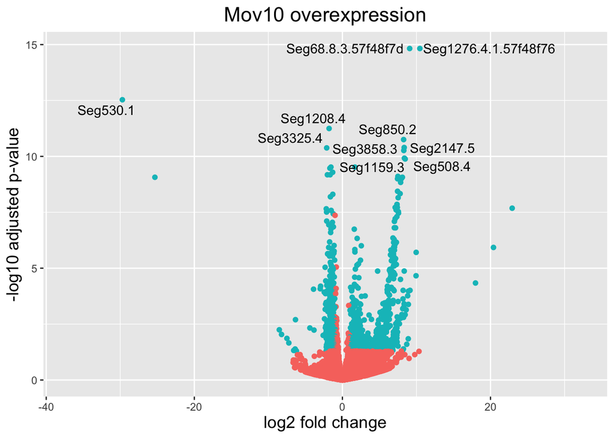

```r
res_tableOE_tb <- res_tableOE_tb %>% arrange(padj) %>% mutate(genelabels = "")

res_tableOE_tb$genelabels[1:10] <- res_tableOE_tb$gene[1:10]

# View(res_tableOE_tb)

ggplot(res_tableOE_tb, aes(x = log2FoldChange, y = -log10(padj))) +
        geom_point(aes(colour = threshold_OE)) +
        geom_text_repel(aes(label = genelabels)) +
        ggtitle("Mov10 overexpression") +
        xlab("log2 fold change") +
        ylab("-log10 adjusted p-value") +
        theme(legend.position = "none",
              plot.title = element_text(size = rel(1.5), hjust = 0.5),
              axis.title = element_text(size = rel(1.25)))
```

## Curated Plotting with data from Alejandro’s killfish/zebrafish paper

### Inspect the overlapping of DGE with reported regeneration programs from literatures

> 1. science S2: 310 shared RRE-regulated genes during killifish and zebrafish regeneration.
> 2. science S3: 546 down-regulated genes shared between killifish and zebrafish (RNA-seq).
> 3. science S4: The regeneration response program is composed of 49 shared genes with RREs and elevated gene expression. A gene with multiple copies in the genome is only counted as one gene.
> 4. science S7: 630 blastema marker genes

```r
# parse the gene lists of interests from literature
s2_shared_rre = read.csv("..//data/secondary/science/s2_shared_310_rre_regulated_genes.csv",)
head(s2_shared_rre)
```

```
##   killifish_genes  zebrafish_proteinID   zebrafish_GeneID zebrafish_genes
## 1       fn1(2of3) ENSDARP00000094530.2 ENSDARG00000006526            fn1b
## 2       fn1(3of3) ENSDARP00000112231.2 ENSDARG00000019815            fn1a
## 3     inhba(2of2) ENSDARP00000006400.7 ENSDARG00000012671          inhbaa
## 4            il11 ENSDARP00000055159.5 ENSDARG00000037859           il11a
## 5     adcy8(3of3) ENSDARP00000082256.4 ENSDARG00000031783           adcy8
## 6     fgf20(2of2) ENSDARP00000007295.6 ENSDARG00000007356          fgf20a
##           zebrafish_description H3K4me3.Peaks.at.the.TSS
## 1               fibronectin 1b                   Present
## 2               fibronectin 1a                   Present
## 3             inhibin, beta Aa                   Present
## 4              interleukin 11a                   Present
## 5  adenylate cyclase 8 (brain)                   Present
## 6 fibroblast growth factor 20a                   Present
```

```r
s4_shared_rrp = read.csv("../data/secondary/science/s4_shared_rrp_49_genes.csv")
head(s4_shared_rrp)
```

```
##   killifish_genes K1dpa_logFC K1dpa_logCPM K1dpa_Pvalue K1dpa_padj
## 1       fn1(2of3)    4.797870    12.601456     8.64e-30   8.84e-27
## 2       fn1(3of3)    3.395728    10.391992     2.14e-26   1.18e-23
## 3     inhba(2of2)    3.256690     3.697904     7.29e-24   2.43e-21
## 4            il11    3.243696     2.475704     5.62e-18   6.77e-16
## 5     adcy8(3of3)    3.087653     3.355765     4.07e-23   1.19e-20
## 6     fgf20(2of2)    3.085989     1.003142     4.83e-15   3.00e-13
##    zebrafish_proteinID   zebrafish_GeneID zebrafish_transcriptID
## 1 ENSDARP00000094530.2 ENSDARG00000006526     ENSDART00000103755
## 2 ENSDARP00000112231.2 ENSDARG00000019815     ENSDART00000124346
## 3 ENSDARP00000006400.7 ENSDARG00000012671     ENSDART00000004241
## 4 ENSDARP00000055159.5 ENSDARG00000037859     ENSDART00000055160
## 5 ENSDARP00000082256.4 ENSDARG00000031783     ENSDART00000087823
## 6 ENSDARP00000007295.6 ENSDARG00000007356     ENSDART00000013024
##   zebrafish_genes         zebrafish_description Z1dpa_logFC Z1dpa_logCPM
## 1            fn1b               fibronectin 1b     5.036695    13.551215
## 2            fn1a               fibronectin 1a     4.916230    11.731614
## 3          inhbaa             inhibin, beta Aa     4.476379     6.523065
## 4           il11a              interleukin 11a     6.133114     3.503219
## 5           adcy8  adenylate cyclase 8 (brain)     3.813507     4.530810
## 6          fgf20a fibroblast growth factor 20a     4.657377     3.748469
##   Z1dpa_Pvalue Z1dpa_padj Common.gene.name H3K4me3.Peaks
## 1    3.74e-223  1.82e-220              fn1       Present
## 2    3.81e-217  1.58e-214              fn1       Present
## 3    3.44e-156  6.34e-154            inhba       Present
## 4    6.36e-160  1.32e-157             il11       Present
## 5     2.55e-72   9.04e-71            adcy8       Present
## 6    2.62e-114  2.48e-112            fgf20       Present
```

```r
s7_blastema_makrkers = read.csv("../data/secondary/science/s7_blastema_marker_genes.csv")
head(s7_blastema_makrkers)
```

```
##   killifish_genes zebrafish_genes kfish_p_val kfish_avg_logFC kfish_pct.1
## 1      apoh(1of3)            ntd5   8.66e-103        1.610672       0.132
## 2     cpxm1(1of2)          cpxm1b    0.00e+00        1.430659       0.365
## 3          pdgfrl          pdgfrl   6.07e-183        2.123618       0.227
## 4  prickle1(2of2)       prickle1b    0.00e+00        2.662258       0.412
## 5      cd34(2of2)  ch211-286o17.1    0.00e+00        6.174117       0.367
## 6     cpxm1(2of2)          cpxm1a   5.76e-217        1.511928       0.266
##   kfish_pct.2   pct_FC kfish_p_val_adj zfish_p_val zfish_avg_logFC zfish_pct.1
## 1       0.003 44.00000        1.29e-98    1.29e-96        1.102527       0.102
## 2       0.009 40.55556        0.00e+00    0.00e+00        1.693475       0.340
## 3       0.006 37.83333       9.07e-179    0.00e+00       11.681811       0.523
## 4       0.011 37.45455        0.00e+00    0.00e+00        3.240729       0.701
## 5       0.011 33.36364        0.00e+00    0.00e+00        7.089220       0.731
## 6       0.008 33.25000       8.60e-213   1.26e-167        1.639132       0.183
##   zfish_pct.2  pct_FC.1 zfish_p_val_adj  max_pval minimump_p_val
## 1       0.005 20.400000        1.93e-92  1.29e-96      1.73e-102
## 2       0.022 15.454545        0.00e+00  0.00e+00       0.00e+00
## 3       0.024 21.791667        0.00e+00 6.07e-183       0.00e+00
## 4       0.124  5.653226        0.00e+00  0.00e+00       0.00e+00
## 5       0.033 22.151515        0.00e+00  0.00e+00       0.00e+00
## 6       0.012 15.250000       1.88e-163 1.26e-167      1.15e-216
```

```r
# parse in the zebrafish-mouse gene mapping
s2.map = read.csv("../data/secondary/science/s2_mus_map.csv")
s4.map = read.csv("../data/secondary/science/s4_mus_map.csv")
s7.map = read.csv("../data/secondary/science/s7_mus_map.csv")

s2_shared_rre.mapped = merge(s2_shared_rre,s2.map,by.x = "zebrafish_GeneID", by.y = "initial_alias") %>%
  filter(ortholog_ensg != "N/A") %>%
  group_by(ortholog_ensg) %>%
  dplyr::slice(1)
head(s2_shared_rre.mapped)
```

```
## # A tibble: 6 x 12
## # Groups:   ortholog_ensg [6]
##   zebrafish_GeneID killifish_genes zebrafish_prote… zebrafish_genes
##   <chr>            <chr>           <chr>            <chr>
## 1 ENSDARG00000029… klf6(1of2)      ENSDARP00000037… klf6a
## 2 ENSDARG00000088… ngfr(1of2)      ENSDARP00000112… ngfra
## 3 ENSDARG00000061… galnt1          ENSDARP00000081… galnt1
## 4 ENSDARG00000006… itga5(1of2)     ENSDARP00000027… itga5
## 5 ENSDARG00000061… sema6b(2of2)    ENSDARP00000131… sema6bb
## 6 ENSDARG00000020… efnb2(1of3)     ENSDARP00000010… efnb2a
## # … with 8 more variables: zebrafish_description <chr>,
## #   H3K4me3.Peaks.at.the.TSS <chr>, g. <int>, initial_ensg <chr>, o. <chr>,
## #   ortholog_name <chr>, ortholog_ensg <chr>, description <chr>
```

```r
s4_shared_rrp.mapped = merge(s4_shared_rrp,s4.map,by.x = "zebrafish_GeneID", by.y = "initial_alias") %>%
  filter(ortholog_ensg != "N/A") %>%
  group_by(ortholog_ensg) %>%
  dplyr::slice(1)
head(s4_shared_rrp.mapped)
```

```
## # A tibble: 6 x 22
## # Groups:   ortholog_ensg [6]
##   zebrafish_GeneID killifish_genes K1dpa_logFC K1dpa_logCPM K1dpa_Pvalue
##   <chr>            <chr>                 <dbl>        <dbl>        <dbl>
## 1 ENSDARG00000061… galnt1                1.06          6.09     3.46e- 9
## 2 ENSDARG00000006… itga5(1of2)           2.58          6.19     1.49e-17
## 3 ENSDARG00000037… il11                  3.24          2.48     5.62e-18
## 4 ENSDARG00000042… tgfbr1                0.853         6.52     6.17e- 7
## 5 ENSDARG00000024… crlf1                 1.39          4.49     3.12e- 9
## 6 ENSDARG00000070… met(1of2)             1.19          5.21     9.75e- 5
## # … with 17 more variables: K1dpa_padj <dbl>, zebrafish_proteinID <chr>,
## #   zebrafish_transcriptID <chr>, zebrafish_genes <chr>,
## #   zebrafish_description <chr>, Z1dpa_logFC <dbl>, Z1dpa_logCPM <dbl>,
## #   Z1dpa_Pvalue <dbl>, Z1dpa_padj <dbl>, Common.gene.name <chr>,
## #   H3K4me3.Peaks <chr>, g. <int>, initial_ensg <chr>, o. <chr>,
## #   ortholog_name <chr>, ortholog_ensg <chr>, description <chr>
```

```r
s7_blastema_makrkers$zebrafish_genes = toupper(s7_blastema_makrkers$zebrafish_genes)
s7_blastema_makrkers.mapped = merge(s7_blastema_makrkers,s7.map,
                                    by.x = "zebrafish_genes", by.y = "initial_alias") %>%
  filter(ortholog_ensg != "N/A") %>%
  group_by(ortholog_ensg) %>%
  dplyr::slice(1)
head(s7_blastema_makrkers.mapped)
```

```
## # A tibble: 6 x 22
## # Groups:   ortholog_ensg [6]
##   zebrafish_genes killifish_genes kfish_p_val kfish_avg_logFC kfish_pct.1
##   <chr>           <chr>                 <dbl>           <dbl>       <dbl>
## 1 AXIN2           axin2(1of2)       0.                   3.40       0.56
## 2 SLC22A18        slc22a18          9.01e-227            1.40       0.511
## 3 GALNT1          galnt1            0.                   3.36       0.598
## 4 RPA1            rpa1(1of2)        2.93e- 80            2.11       0.394
## 5 OXA1L           oxa1l             0.                   2.40       0.735
## 6 COL6A1          col6a1(1of2)      0.                  47.8        0.982
## # … with 17 more variables: kfish_pct.2 <dbl>, pct_FC <dbl>,
## #   kfish_p_val_adj <dbl>, zfish_p_val <dbl>, zfish_avg_logFC <dbl>,
## #   zfish_pct.1 <dbl>, zfish_pct.2 <dbl>, pct_FC.1 <dbl>,
## #   zfish_p_val_adj <dbl>, max_pval <dbl>, minimump_p_val <dbl>, g. <int>,
## #   initial_ensg <chr>, o. <chr>, ortholog_name <chr>, ortholog_ensg <chr>,
## #   description <chr>
```

### For the 4 comparison groups, add 3 columns of whether the gene overlap with literature

```r
res.rege.sig
```

```
## # A tibble: 685 x 7
##    gene     baseMean log2FoldChange lfcSE  stat   pvalue     padj
##    <chr>       <dbl>          <dbl> <dbl> <dbl>    <dbl>    <dbl>
##  1 Seg3.15    619.            -1.61 0.380 -4.22 2.39e- 5 1.51e- 3
##  2 Seg5.10     20.6            8.26 1.96   4.21 2.55e- 5 1.58e- 3
##  3 Seg6.7     161.             1.78 0.565  3.14 1.67e- 3 3.73e- 2
##  4 Seg10.4     14.2            7.38 1.10   6.70 2.03e-11 1.41e- 8
##  5 Seg16.5    120.             1.50 0.346  4.33 1.48e- 5 1.03e- 3
##  6 Seg18.9     13.2            2.49 0.807  3.08 2.07e- 3 4.30e- 2
##  7 Seg23.13    22.9            7.45 1.05   7.12 1.04e-12 9.96e-10
##  8 Seg31.1     13.2            7.56 1.15   6.56 5.24e-11 2.94e- 8
##  9 Seg32.5      4.34           5.91 1.88   3.15 1.66e- 3 3.72e- 2
## 10 Seg43.5      9.32           7.03 1.20   5.83 5.50e- 9 1.57e- 6
## # … with 675 more rows
```

```r
blastx_anno_ensm = read.csv("../out/blastx_aurelia_mus_map_ensm.csv")
blastx_anno_ensm = blastx_anno_ensm %>%
  filter(name != "nan")
# blastx_anno_ensm
annotate.overlap = function(dge.df,gene.list.s2,gene.list.s4,gene.list.s7) {
  df_merged = merge(dge.df, blastx_anno, by.x = "gene", by.y = "query.acc.ver")
  df_merged_anno = dplyr::select(df_merged,c("gene","log2FoldChange","padj","subject.acc.ver","evalue"))
  df_merged_anno_ensm = merge(df_merged_anno, blastx_anno_ensm, by.x = "subject.acc.ver", by.y = "initial_alias")
  df_merged_anno_ensm$in.rre = (df_merged_anno_ensm$converted_alias %in% gene.list.s2)
  df_merged_anno_ensm$in.rrp = (df_merged_anno_ensm$converted_alias %in% gene.list.s4)
  df_merged_anno_ensm$in.blastema = (df_merged_anno_ensm$converted_alias %in% gene.list.s7)
  df_merged_anno_ensm = df_merged_anno_ensm %>%
    group_by(converted_alias) %>%
    dplyr::slice(1) %>%
    data.frame()
  return(df_merged_anno_ensm)
}

sec.res.rege.sig = annotate.overlap(res.rege.sig,s2_shared_rre.mapped$ortholog_ensg,
                 s4_shared_rrp.mapped$ortholog_ensg,
                 s7_blastema_makrkers.mapped$ortholog_ensg)

sec.res.rege27.sig = annotate.overlap(res.rege27.sig,s2_shared_rre.mapped$ortholog_ensg,
                 s4_shared_rrp.mapped$ortholog_ensg,
                 s7_blastema_makrkers.mapped$ortholog_ensg)

sec.res.rege51.sig = annotate.overlap(res.rege51.sig,s2_shared_rre.mapped$ortholog_ensg,
                 s4_shared_rrp.mapped$ortholog_ensg,
                 s7_blastema_makrkers.mapped$ortholog_ensg)

sec.res.ampu.sig = annotate.overlap(res.ampu.sig,s2_shared_rre.mapped$ortholog_ensg,
                 s4_shared_rrp.mapped$ortholog_ensg,
                 s7_blastema_makrkers.mapped$ortholog_ensg)
```

### number genes overlapping between DGE result and literature report

```r
colSums(sec.res.rege.sig[,c(10,11,12)])
```

```
##      in.rre      in.rrp in.blastema
##           4           1          22
```

```r
colSums(sec.res.rege27.sig[,c(10,11,12)])
```

```
##      in.rre      in.rrp in.blastema
##          22           4          35
```

```r
colSums(sec.res.rege51.sig[,c(10,11,12)])
```

```
##      in.rre      in.rrp in.blastema
##           2           0          17
```

```r
colSums(sec.res.ampu.sig[,c(10,11,12)])
```

```
##      in.rre      in.rrp in.blastema
##          11           2          27
```

### Plot Heatmap with gene labels for the overlapped genes

#### regeneration VS non-regeneration at 27h DGE overlap with regeneration elements

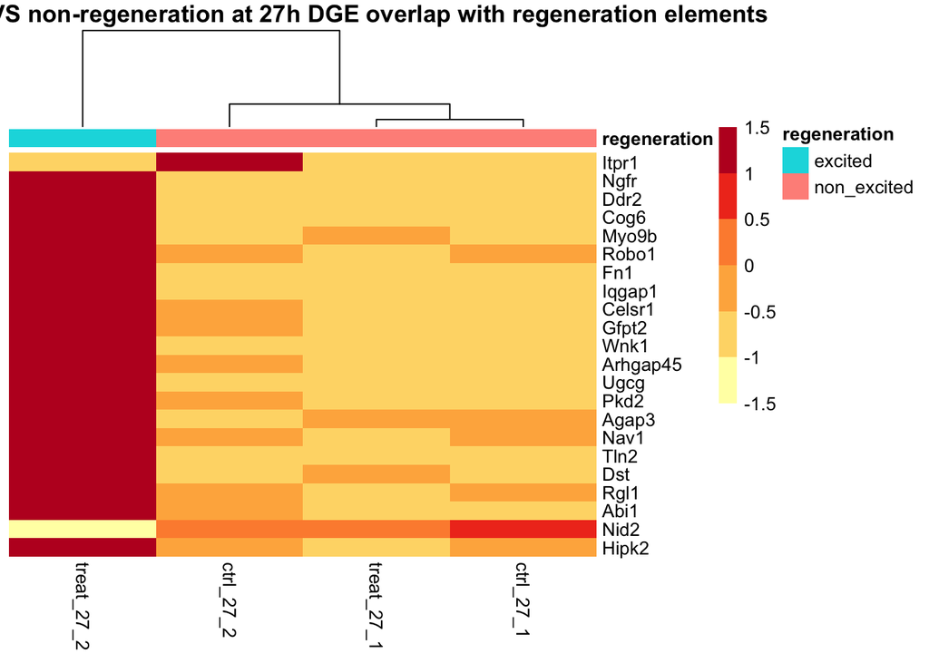

```r
norm_OEsig <- normalized_counts[,c(1,2,3,10,11)] %>%
              filter(gene %in% sec.res.rege27.sig$gene[sec.res.rege27.sig$in.rre]) %>%
          data.frame()
norm_OEsig = merge(norm_OEsig,select(sec.res.rege27.sig,c("gene","name")),by = "gene") %>%
  column_to_rownames(var = "name") %>%
  select(-gene)

# norm_OEsig

### Annotate our heatmap (optional)
annotation <- metadata %>%
    select(sample, regeneration) %>%
    data.frame(row.names = "sample")
# annotation
### Set a color palette
heat_colors <- brewer.pal(6, "YlOrRd")

### Run pheatmap
pheatmap(norm_OEsig,
         color = heat_colors,
         cluster_rows = F,
         show_rownames = T,
         annotation = annotation,
         border_color = NA,
         fontsize = 10,
         scale = "row",
         fontsize_row = 10,
         height = 20,
         main = "regeneration VS non-regeneration at 27h DGE overlap with regeneration elements")
```

#### regeneration VS non-regeneration at 27h DGE overlap with literature blastema markers

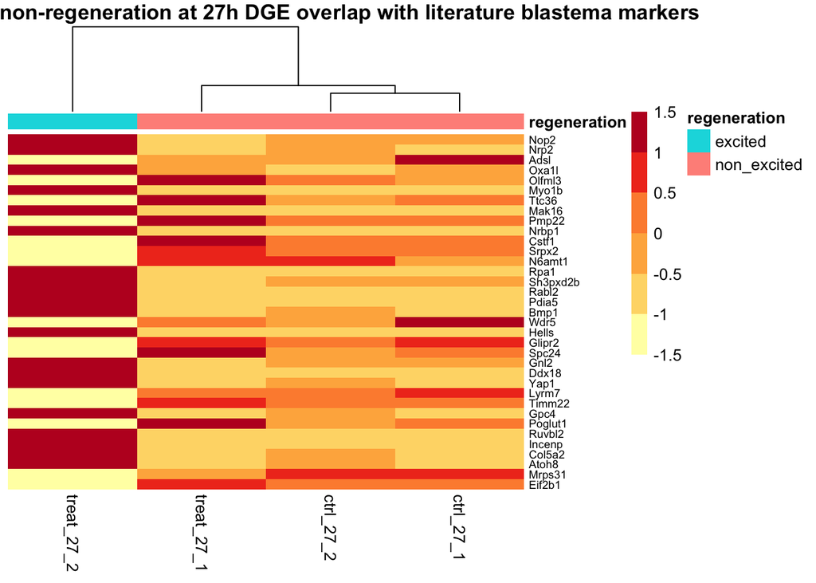

```r
norm_OEsig <- normalized_counts[,c(1,2,3,10,11)] %>%
              filter(gene %in% sec.res.rege27.sig$gene[sec.res.rege27.sig$in.blastema]) %>%
          data.frame()
norm_OEsig = merge(norm_OEsig,select(sec.res.rege27.sig,c("gene","name")),by = "gene") %>%
  column_to_rownames(var = "name") %>%
  select(-gene)

# norm_OEsig

### Annotate our heatmap (optional)
annotation <- metadata %>%
    select(sample, regeneration) %>%
    data.frame(row.names = "sample")
# annotation
### Set a color palette
heat_colors <- brewer.pal(6, "YlOrRd")

### Run pheatmap
pheatmap(norm_OEsig,
         color = heat_colors,
         cluster_rows = F,
         show_rownames = T,
         annotation = annotation,
         border_color = NA,
         fontsize = 10,
         scale = "row",
         fontsize_row = 7,
         height = 20,
         main = "regeneration VS non-regeneration at 27h DGE overlap with literature blastema markers")
```

### regeneration VS non-regeneration (27h+51h) DGE overlap with literature blastema markers

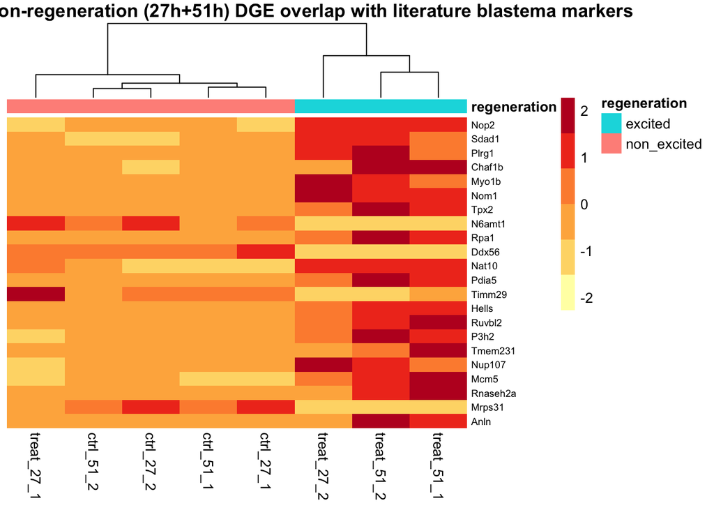

```r
norm_OEsig <- normalized_counts[,c(1,2,3,6,7,8,9,10,11)] %>%
              filter(gene %in% sec.res.rege.sig$gene[sec.res.rege.sig$in.blastema]) %>%
          data.frame()

norm_OEsig = merge(norm_OEsig,select(sec.res.rege.sig,c("gene","name")),by = "gene") %>%
  column_to_rownames(var = "name") %>%
  select(-gene)

# norm_OEsig

### Annotate our heatmap (optional)
annotation <- metadata %>%
    select(sample, regeneration) %>%
    data.frame(row.names = "sample")
# annotation
### Set a color palette
heat_colors <- brewer.pal(6, "YlOrRd")

### Run pheatmap
pheatmap(norm_OEsig,
         color = heat_colors,
         cluster_rows = F,
         show_rownames = T,
         annotation = annotation,
         border_color = NA,
         fontsize = 10,
         scale = "row",
         fontsize_row = 7,
         height = 20,
         main = "regeneration VS non-regeneration (27h+51h) DGE overlap with literature blastema markers")
```